# Cyclistic Bike Share

```r
options(repos = c(CRAN = "https://cloud.r-project.org/"))
```

## Programmed and Analyzed by: Michael Gonzalez

### Date: 2024

### Overview

In 2016, Cyclistic, a bike-share company based in Chicago, launched its bike-sharing program with a fleet of 5,824 bicycles distributed across 692 stations. The program has since grown and become popular among both locals and tourists, offering a flexible and convenient transportation option. Cyclistic distinguishes itself by providing a range of bicycles, including traditional bikes, reclining bikes, hand tricycles, and cargo bikes, making the service inclusive for people with disabilities. The company’s primary focus has been on building brand awareness and attracting a broad consumer base through flexible pricing plans, including single-ride passes, full-day passes, and annual memberships. Cyclistic’s finance team has identified that annual members are significantly more profitable than casual riders, prompting the marketing team to explore strategies to convert casual riders into annual members.

The company’s success depends on maximizing the number of annual memberships, which led to the initiation of this project. The project aims to analyze how different user segments-casual riders and annual members-utilize Cyclistic’s bike-sharing service, with the goal of identifying actionable insights that can drive marketing strategies to increase membership conversion rates.

### Project Definition

The primary objective of this project is to understand the usage patterns of Cyclistic’s bike-sharing service between two key user segments: casual riders and annual members. By analyzing historical bike trip data, the project seeks to uncover significant differences in how these two groups use the service, with the ultimate goal of informing a new marketing strategy that encourages casual riders to become annual members.

The project is structured around answering three central questions:

How do annual members and casual riders use Cyclistic bikes differently? Why would casual riders be motivated to purchase annual memberships? How can digital media be leveraged to influence casual riders to convert to annual members? This analysis will be used to create data-driven recommendations for Cyclistic’s marketing team, ensuring that the proposed strategies are backed by compelling insights and visualizations that can effectively communicate the findings to the company’s executive team.

### Personal Notes

- Took out Ride Duration Minutes that were greater than 2880 minutes (48 hours) because it is not accurate to the population
- Took out Ride Duration Minutes that were less than or equal to 0 minutes because it is not acurate to the population.
- Comment out str(RidaDataForV1), head(RidaDataForV1), print(rides_data_sorted), print(rides_data), “data.frame”, class(RidaDataForV1), names(RidaDataForV1), head(RidaDataForV1), theme minimal
- Had to rename the columns for each year so that they would match with each other
- 2019, trip_id to ride_id (Different), *start_time,* end_time, bikeid, (DROP), *tripduration, (DROP),* from_station_id, *from_station_name,* to_station_id, *to_station_name,* usertype, (RENAME TO member_casual), gender, (DROP), birthyear, (DROP), *ride_length,* day_of_week, month_of_the_year
- 2020, ride_id, rideable_type, (DROP THERES ONLY 1 VARIABLE AND COLUMN IS MISSING IN 2019), started_at, (Renamed to started_time), ended_at, (Renamed to started_time), start_station_name, start_station_id, end_station_name, end_station_id, start_lat, (DROP), start_lng, (DROP), end_lat, (DROP), end_lng, (DROP), member_casual, ride_length, day_of_week, ADD month_of_the_year
- Installed packaged “ggplot2”, “tidyverse”, “DBI”, “RSQLite”, “magrittr”, “dplyr”, “htmltools”, “lubrdidate”, “scales”

```r
# Data Visualization:
#install.packages("ggplot2")
#install.packages("scales")

# Data Manipulation:
#install.packages("tidyverse")
#install.packages("dplyr")

# Database Mangement:
#install.packages("DBI")

# Connects SQL Database to R Database:
#install.packages("RSQLite")

# Offers Operators:
#install.packages("magrittr")

# Customize User Interface:
#install.packages("htmltools")

#Organizes Date and Time Data:
#install.packages("lubridate")

# Grouping Multiple Variables:
#install.packages("xfun")

# Allows to Read Factors
#install.packages("readr")
```

```r
# Suppress Warnings
# To Reanable Warnings set warn = 0
options(warn = -1)
```

```r
library(ggplot2)
library(tidyverse)
library(DBI)
library(RSQLite)
library(magrittr)
library(dplyr)
library(htmltools)
library(lubridate)
library(scales)
library(xfun)
library(readr)
```

```r
#packageVersion("htmltools")
```

```r
#packageVersion("xfun")
```

```r
#update.packages(ask = FALSE)
```

```r
print_stats <- function(bp_info){
  for(i in 1:length(bp_info$n)) {
    cat("  BoxPlot Category = ",bp_info$names[i], "\n")
    cat("  Upper Whisker: ",bp_info$stats[5, i], "\n")
    cat("  Q3           : ",bp_info$stats[4, i], "\n")
    cat("  Median       : ",bp_info$stats[3, i], "\n")
    cat("  Q1           : ",bp_info$stats[2, i], "\n")
    cat("  Lower Whisker: ",bp_info$stats[1, i], "\n")
    cat("  Q3 - Q1      : ",bp$stats[4, i] - bp_info$stats[2, i], "\n\n")
  }
}
```

### Read in the Data File

```r
RidaDataForRV1 <- read.csv("C:\\Users\\mjgon\\OneDrive\\Desktop\\Case Study Data\\csv files\\RidaDataFOrRV1.csv")
#head(RidaDataForRV1)
```

### Based on analysis I came to the conclusion that records needed to be removed as there were negative durations.

```r
conn <- dbConnect(RSQLite::SQLite(), dbname = "C:\\Users\\mjgon\\OneDrive\\Desktop\\Case Study Data\\csv files\\Cyclistic_DB")
query <- "SELECT *
FROM RideData
WHERE ride_duration_minutes <= 0"

RidaDataForRV1 <- RidaDataForRV1 %>%
  filter(ride_duration_minutes > 0)

#print(RidaDataForRV1)


dbDisconnect(conn)
```

```r
RidaDataForRV1 <- RidaDataForRV1 %>%
  filter(ride_duration_minutes < 2880)

#print(RidaDataForRV1)
```

```r
RidaDataForRV1 <- RidaDataForRV1 %>%
  mutate(week_of_year = week(ymd_hms(started_time)))

# View the updated data
#print(RidaDataForRV1)
distinct_weeks <- RidaDataForRV1 %>%
  distinct(week_of_year) %>%
  arrange(week_of_year)
#print(distinct_weeks)
```

```r
conn <- dbConnect(RSQLite::SQLite(), dbname = "C:\\Users\\mjgon\\OneDrive\\Desktop\\Case Study Data\\csv files\\Cyclistic_DB")
query <- "SELECT *
FROM RideData
WHERE ride_duration_minutes >= 2880"

result <- dbGetQuery(conn, query)
#print(result)

dbDisconnect(conn)
```

```r
RidaDataForRV1 <- read.csv("file:///C:/Users/mjgon/OneDrive/Desktop/Case Study Data/csv files/RidaDataForRV1.csv")
#head(RidaDataForRV1)
```

### Walkthrough:

- What is the breakdown of the Customer versus Subscriber by Number of Rides?

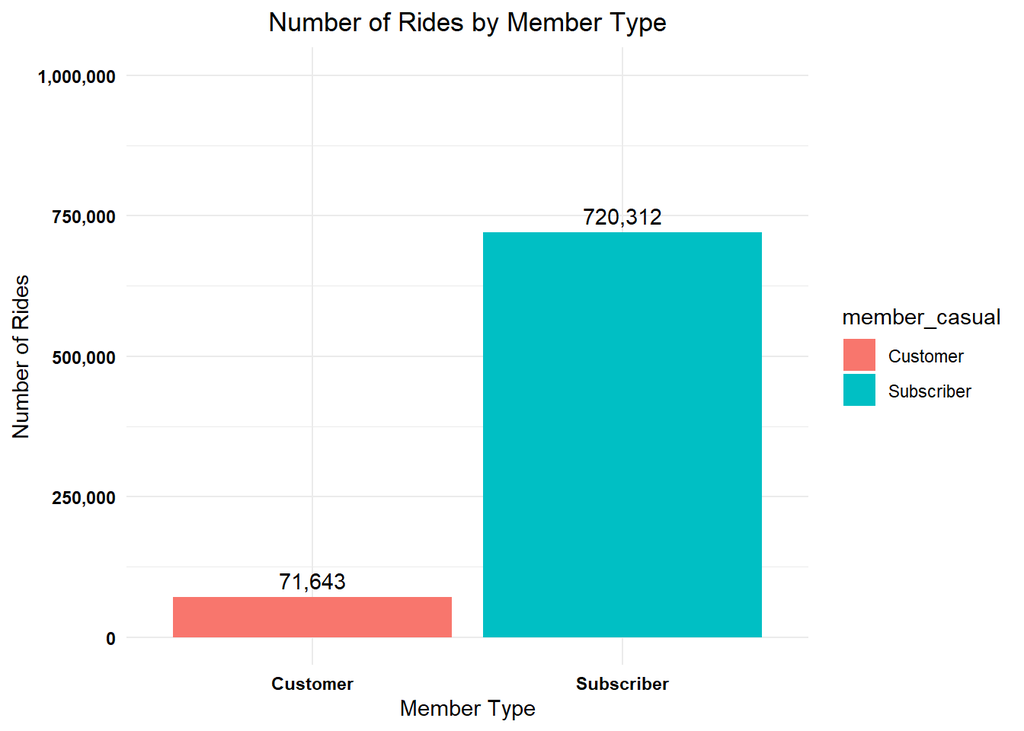

```r
rides_data <- RidaDataForRV1 %>%
  group_by(member_casual) %>%
  summarise(num_rides = n())

ggplot(rides_data, aes(x = member_casual, y = num_rides, fill = member_casual)) +
  geom_bar(stat = "identity") +
  geom_text(aes(label = scales::comma(num_rides)), vjust = -0.5) +  # Using scales::comma to format labels
  scale_y_continuous(labels = scales::comma, limits = c(0, 1000000)) +  # Adjust the upper limit to add more space
  labs(title = "Number of Rides by Member Type",
       x = "Member Type",
       y = "Number of Rides") +
  theme_minimal() +
  theme(
    axis.text.x = element_text(color = "black", face = "bold"),
    axis.text.y = element_text(color = "black", face = "bold"),
    plot.title = element_text(hjust = 0.5)
  )
```

#### Observations:

- This is the breakdown of the Number of Rides by Customers and Subscribers. It is shown that there are 71,643 Customers and 720,312 Subscribers. By this basic breakdown, it is evident that there are far more Subscribers than Customers in the combined dataset.

### Walkthrough:

- What is the breakdown of Customer and Subscriber by Number of Rides and by Year?

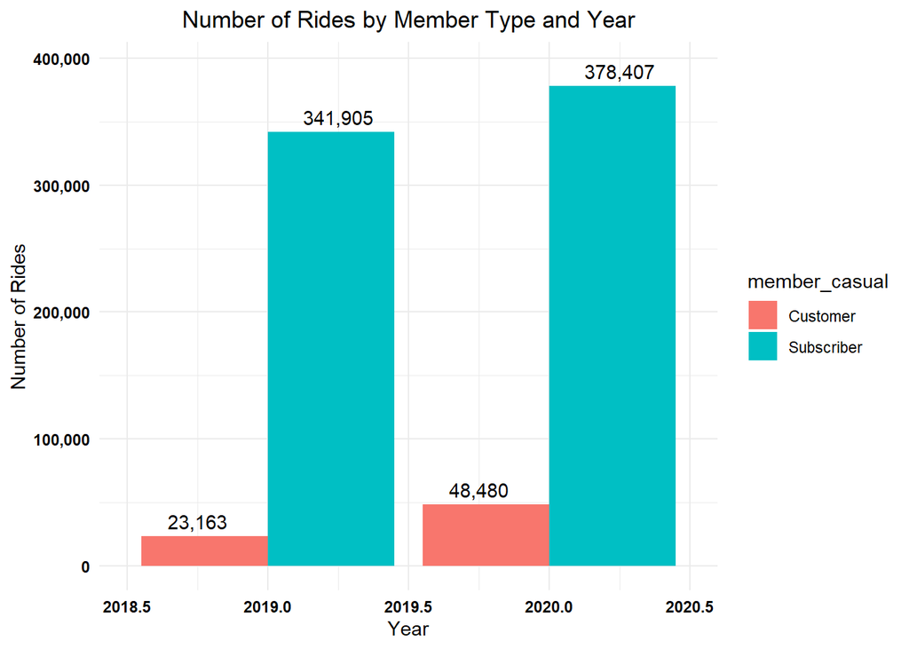

```r
rides_data <- RidaDataForRV1 %>%
  mutate(year = year(started_time)) %>%  # Extract the year from 'started_time'
  group_by(member_casual, year) %>%
  summarise(num_rides = n(), .groups = 'drop')

# Create the bar chart
ggplot(rides_data, aes(x = year, y = num_rides, fill = member_casual)) +
  geom_bar(stat = "identity", position = "dodge") +  # 'dodge' to place bars side by side for each year
  geom_text(aes(label = scales::comma(num_rides)), vjust = -0.5, position = position_dodge(width = 1)) +  # Format labels
  scale_y_continuous(labels = scales::comma, limits = c(0, max(rides_data$num_rides) + 15000)) +  # Adjust y-axis limit for space
  labs(title = "Number of Rides by Member Type and Year",
       x = "Year",
       y = "Number of Rides") +
  theme_minimal() +
  theme(
    axis.text.x = element_text(color = "black", face = "bold"),
    axis.text.y = element_text(color = "black", face = "bold"),
    plot.title = element_text(hjust = 0.5)
  )
```

#### Observations:

- It is clear that for both years that Subscribers have many more Number of Rides than Customers.

### Walkthrough:

- What does the Number of Rides and Hour of Day breakdown into by each member type?

```r
rides_data <- RidaDataForRV1 %>%
  group_by(member_casual, hour_of_day) %>%
  summarise(num_rides = n()) %>%
  ungroup()
```

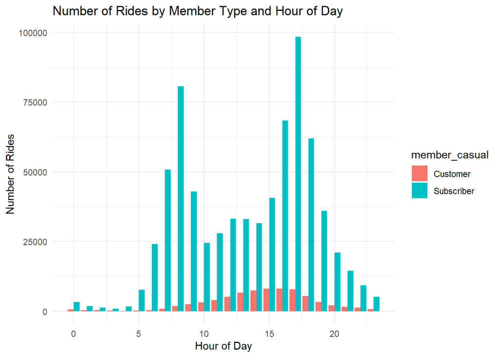

```r
#print(rides_data)

#rides_data_sorted <- rides_data %>%
 # group_by(member_casual, hour_of_day) %>%
  #arrange(desc(num_rides)) %>%
#print(rides_data_sorted)

ggplot(rides_data, aes(x = hour_of_day, y = num_rides, fill = member_casual)) +
  geom_bar(stat = "identity", position = "dodge") +
  #geom_text(aes(label = num_rides), vjust = -0.5) +
  labs(title = "Number of Rides by Member Type and Hour of Day",
       x = "Hour of Day", y = "Number of Rides") +
  theme_minimal()
```

```r
#top_3_data <- rides_data_sorted
#  arrange(desc(num_rides)) %>%
 # slice_head(n = 3)
#print(top_3_data)
```

#### Observations:

- This Bar Chart shows how often that Subscribers and Cusomters use the bikes during the Hour of Day. The graph indicates that for Subscribers is at its peak at 8am and 5 pm. For Customers it is at its peak during the hours of 3pm and 5pm. If I were on the marketing team I would advertise to the Customers at the time of 1 pm to 6 pm which is when the highest number of rides is occuring for Customers.

### Walkthrough:

- How does the Number of Rides and Member Type look like by Day Name?

```r
#rides_data <- data.frame(
 # member_casual = rep(c("Subscriber", "Customer"), each = 7),
  #day_of_week = rep(c("Mon", "Tue", "Wed", "Thu", "Fri", "Sat", "Sun"), times = 2),
  #num_rides = c(100, 150, 120, 130, 170, 190, 200, 90, 80, 70, 60, 110, 130, 140)
#)
#print(rides_data)

rides_data <- RidaDataForRV1 %>%
  group_by(member_casual, day_name) %>%
  summarise(num_rides = n()) %>%
  ungroup()
```

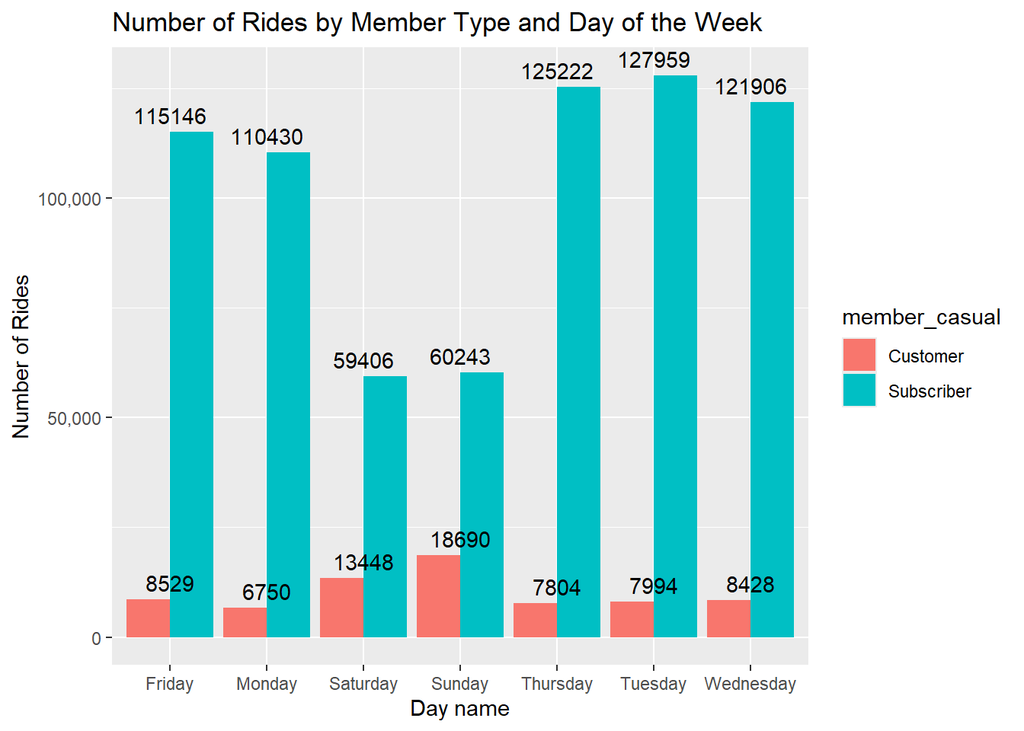

```r
#print(rides_data)

#rides_data_sorted <- rides_data %>%
 # group_by(member_casual, day_name) %>%
  #arrange(desc(num_rides)) %>%
#print(rides_data_sorted)

#top_3_data <- rides_data_sorted
#  arrange(desc(num_rides)) %>%
 # slice_head(n = 3)
#print(top_3_data)


ggplot(rides_data, aes(x = day_name, y = num_rides, fill = member_casual)) +
  geom_bar(stat = "identity", position = "dodge") +
  geom_text(aes(label = num_rides), vjust = -0.5) +
  ylim(0, 130000) +
  scale_y_continuous(labels = scales::comma) +
  labs(title = "Number of Rides by Member Type and Day of the Week",
       x = "Day name", y = "Number of Rides")
```

```r
  #theme_minimal()
```

#### Observations:

- This graph shows the Number of Rides and the Day of the Week using a Bar Chart. This graph shows that Subscribers use this service far more than the Customers especially during the weekdays. This indicates that the Subscribers are likely using this service to go to work while the Customers are using this service for entertainment purposes. I would suggest advertising to the Customers on Saturdays and Subdays as these days are when the Customers are using the service the most. By using this marketing strategy, the company can try and convert as many Customers into Subscribers.

### Walkthrough:

- What is the breakdown of Customer versus Subscriber by Number of Rides and Month of Year?

```r
rides_data <- RidaDataForRV1 %>%
  group_by(member_casual, month_of_year) %>%
  summarise(num_rides = n()) %>%
  ungroup()
```

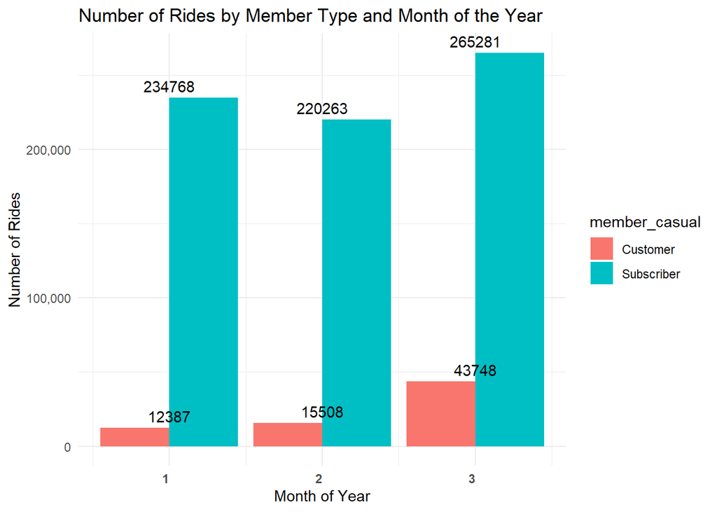

```r
ggplot(rides_data, aes(x = month_of_year, y = num_rides, fill = member_casual)) +
  geom_bar(stat = "identity", position = "dodge") +
  geom_text(aes(label = num_rides), vjust = -0.5) +
  scale_y_continuous(labels = scales::comma) +
  labs(title = "Number of Rides by Member Type and Month of the Year",
       x = "Month of Year",
       y = "Number of Rides") +
  theme_minimal() +
  theme(axis.text.x = element_text(angle = 0, hjust = 1, face = "bold"))
```

#### Observations:

- It is clear that Subscribers have many more Number of Rides than Customers regardless of the Month of Year. Interestingly for Customers, as the Months go on the Number of Rides also increases.

### Walkthrough:

- How do the Member Type ride differently by Duration in Minutes and by Day of the Week?

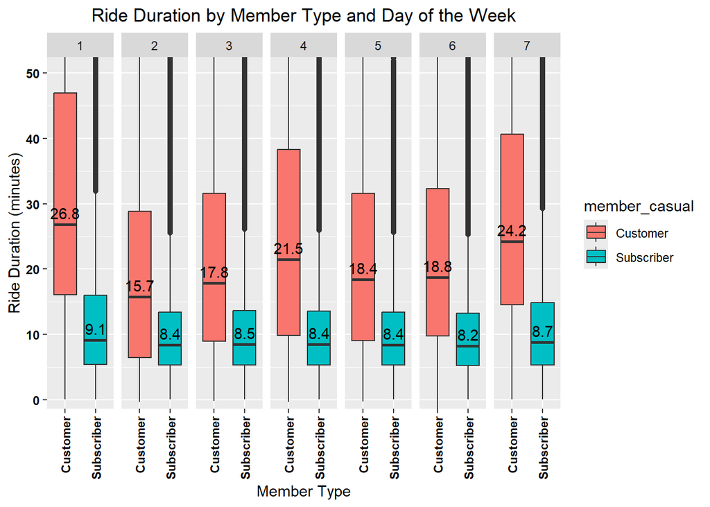

```r
ggplot(RidaDataForRV1, aes(x = member_casual, y = ride_duration_minutes, fill = member_casual)) +
  geom_boxplot() +
  stat_summary(fun = median, geom = "text", aes(label = round(..y.., 1)),
               position = position_dodge(width = 0.75), vjust = -0.5, color = "black") +
  facet_wrap(~ day_of_week, ncol = length(unique(RidaDataForRV1$day_of_week))) +
  coord_cartesian(ylim = c(1, 50)) + #This is for the range to zoom in
  labs(title = "Ride Duration by Member Type and Day of the Week", x = "Member Type", y = "Ride Duration (minutes)") +
  theme(axis.text.x = element_text(angle = 90, hjust = 1, vjust = 0.5)) +
  theme(
    axis.text.x = element_text(color = "black", face = "bold"),
    axis.text.y = element_text(color = "black", face = "bold"),
    plot.title = element_text(hjust = 0.5)
  )
```

```r
#for(i in 1:length(bp$n)) {
 # text(i, bp$stats[1, i], labels = round(bp$stats[1, i], 2), pos   = 1, cex = 0.8)
  #text(i, bp$stats[2, i], labels = round(bp$stats[2, i], 2), pos   = 1, cex = 0.8)
  #text(i, bp$stats[3, i], labels = round(bp$stats[3, i], 2), pos   = 3, cex = 0.8)
  #text(i, bp$stats[4, i], labels = round(bp$stats[4, i], 2), pos   = 1, cex = 0.8)
  #text(i, bp$stats[5, i], labels = round(bp$stats[5, i], 2), pos   = 3, cex = 0.8)
#}
```

#### Observations:

- This Multi Box and Whisker Plot shows the Ride Duration in Minutes by Each Day of the Week and is also broker down by Customer and Subscriber. It is shown that the median ride duration is higher from Customers as opposed to Subscribers. This could be due to the Customers using the Bike Service for entertainment purposes or to site see. The Subscribers may be using the Bike Service to and from work. The day of the week also supports this theory as Saturday and Sunday are higher within Customers for Ride Duration and lower during the weekdays.

### Walkthrough:

- What is the Ride Duration in Minutes by Customer versus Subscriber and by Week of Year in 2019?

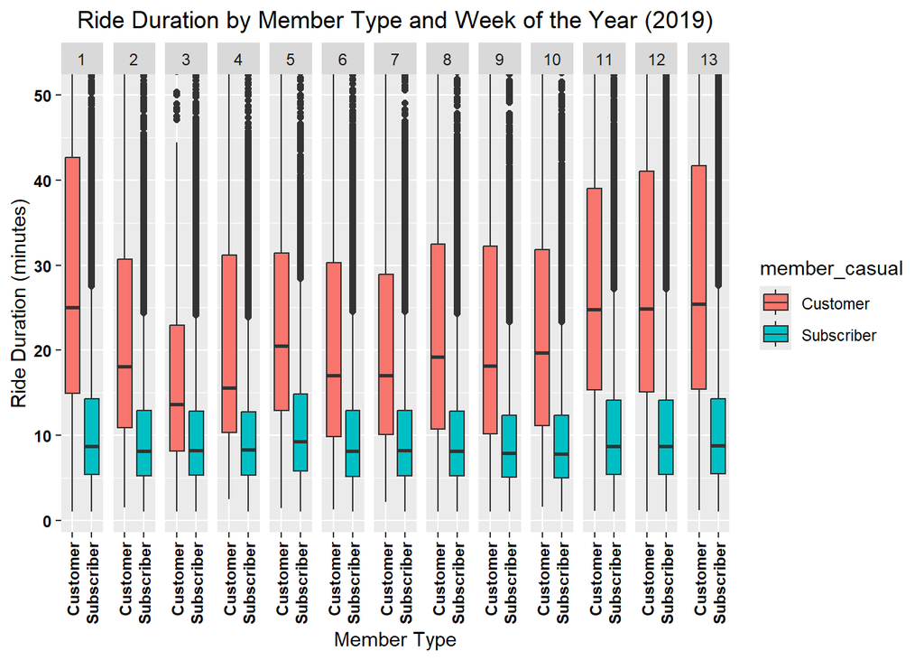

```r
# Filter data for the year 2019
RidaDataForRV1_2019 <- RidaDataForRV1 %>%
  filter(year(started_time) == 2019) %>%  # Filter data for 2019
  mutate(week_of_year = isoweek(started_time))  # Extract ISO week number

# Create the boxplot
ggplot(RidaDataForRV1_2019, aes(x = member_casual, y = ride_duration_minutes, fill = member_casual)) +
  geom_boxplot() +
  #stat_summary(fun = median, geom = "text", aes(label = round(..y.., 1)),
   #            position = position_dodge(width = 0.75), vjust = -0.5, color = "black") +
  facet_wrap(~ week_of_year, ncol = 13) +  # Adjust number of columns to fit weeks of the year
  coord_cartesian(ylim = c(1, 50)) +  # Zoom in on the range
  labs(title = "Ride Duration by Member Type and Week of the Year (2019)",
       x = "Member Type",
       y = "Ride Duration (minutes)") +
  theme(axis.text.x = element_text(angle = 90, hjust = 1, vjust = 0.5)) +
  theme(
    axis.text.x = element_text(color = "black", face = "bold"),
    axis.text.y = element_text(color = "black", face = "bold"),
    plot.title = element_text(hjust = 0.5)
  )
```

#### Observations:

- This Box and Whisker Geaph looks at Ride Duration in Minutes by the Week of the Year in 2019 and breaks it down by Customer and Subscriber. It can be shown that in Weeks 1, 12, and 13 the Median is above the other weeks for Customers. This means that toward the start of the year and toward the end of March the Customers are using the service more than the middle weeks.

### Walkthrough:

- What is the Ride Duration in Minutes by Customer versus Subscriber and by Week of Year in 2020?

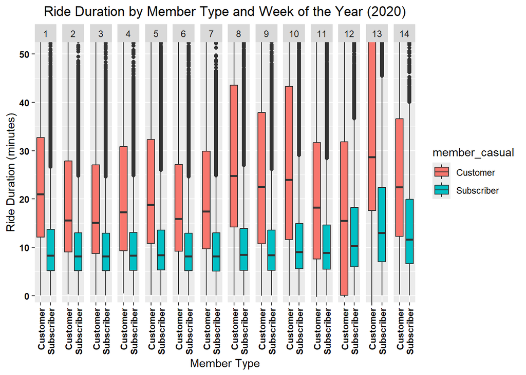

```r
# Filter data for the year 2020
RidaDataForRV1_2020 <- RidaDataForRV1 %>%
  filter(year(started_time) == 2020) %>%  # Filter data for 2020
  mutate(week_of_year = isoweek(started_time))  # Extract ISO week number

# Create the boxplot
ggplot(RidaDataForRV1_2020, aes(x = member_casual, y = ride_duration_minutes, fill = member_casual)) +
  geom_boxplot() +
  #stat_summary(fun = median, geom = "text", aes(label = round(..y.., 1)),
               #position = position_dodge(width = 0.75), vjust = -0.5, color = "black") +
  facet_wrap(~ week_of_year, ncol = 13) +  # Adjust number of columns to fit weeks of the year
  facet_wrap(~ week_of_year, nrow = 1) +  # Arrange all plots in a single row
  coord_cartesian(ylim = c(1, 50)) +  # Zoom in on the range
  labs(title = "Ride Duration by Member Type and Week of the Year (2020)",
       x = "Member Type",
       y = "Ride Duration (minutes)") +
  theme(axis.text.x = element_text(angle = 90, hjust = 1, vjust = 0.5)) +
  theme(
    axis.text.x = element_text(color = "black", face = "bold"),
    axis.text.y = element_text(color = "black", face = "bold"),
    plot.title = element_text(hjust = 0.5)
  )
```

#### Observations:

- On Week 13 the Median for Customers went up drastically as opposed to the other weeks. This is similar to the 2019 Data, it could be that towards the end of March that the Customers use the bike service for longer.

### Walkthrough:

- How does the Member Type ride differently by Duration in Minutes and by the Top 5 Start Station Names?

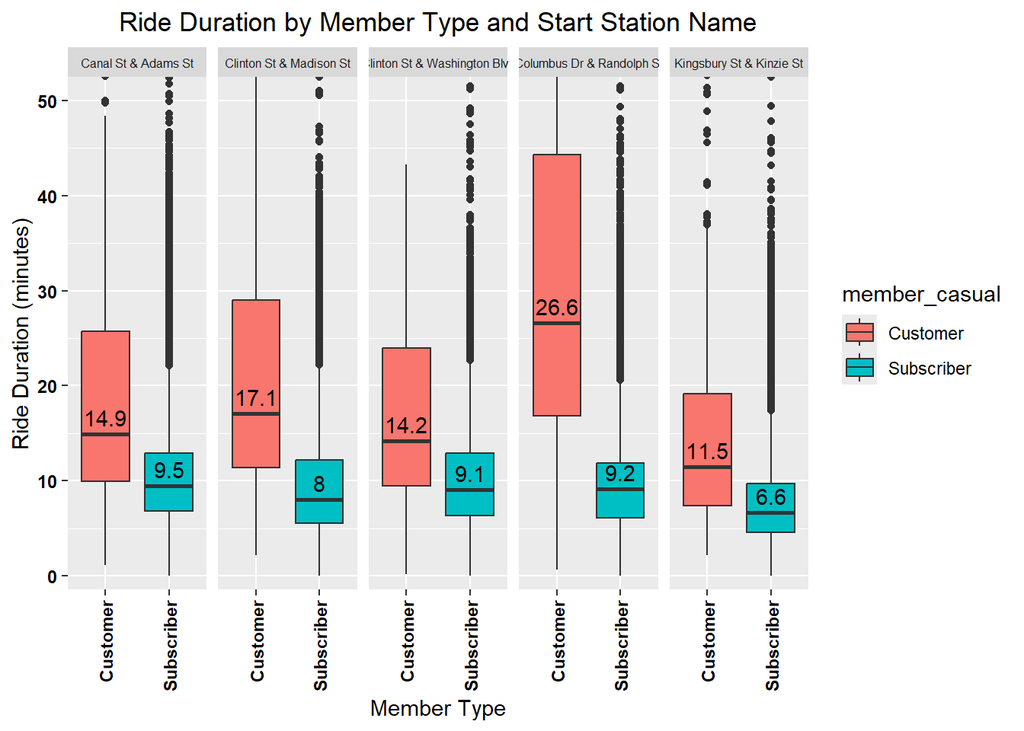

```r
top_stations <- RidaDataForRV1 %>%
  group_by(start_station_name) %>%
  summarise(num_rides = n()) %>%
  arrange(desc(num_rides)) %>%
  slice_head(n = 5)
filtered_data <- RidaDataForRV1 %>%
  filter(start_station_name %in% top_stations$start_station_name)
ggplot(filtered_data, aes(x = member_casual, y = ride_duration_minutes, fill = member_casual)) +
  geom_boxplot() +
  stat_summary(fun = median, geom = "text", aes(label = round(..y.., 1)),
               position = position_dodge(width = 0.75), vjust = -0.5, color = "black") +
  facet_wrap(~ start_station_name, ncol = length(unique(RidaDataForRV1$start_station_name))) +
  coord_cartesian(ylim = c(1, 50)) + #This is for the range to zoom in
  labs(title = "Ride Duration by Member Type and Start Station Name", x = "Member Type", y = "Ride Duration (minutes)") +
  theme(axis.text.x = element_text(angle = 90, hjust = 1, vjust = 0.5)) +
  theme(
    axis.text.x = element_text(color = "black", face = "bold"),
    axis.text.y = element_text(color = "black", face = "bold"),
    plot.title = element_text(hjust = 0.5),
    strip.text = element_text(size = 6)
  )
```

#### Observations:

- This Multi Box and Whisker Plot shows the Ride Duration in Minutes by Start Station Name and member type. It is evident that Colombus Dr has the highest median for Customers

### Walkthrough:

- What is the change of Number of Rides by Customers and Subscribers over the Number of Weeks in both 2019 and 2020?

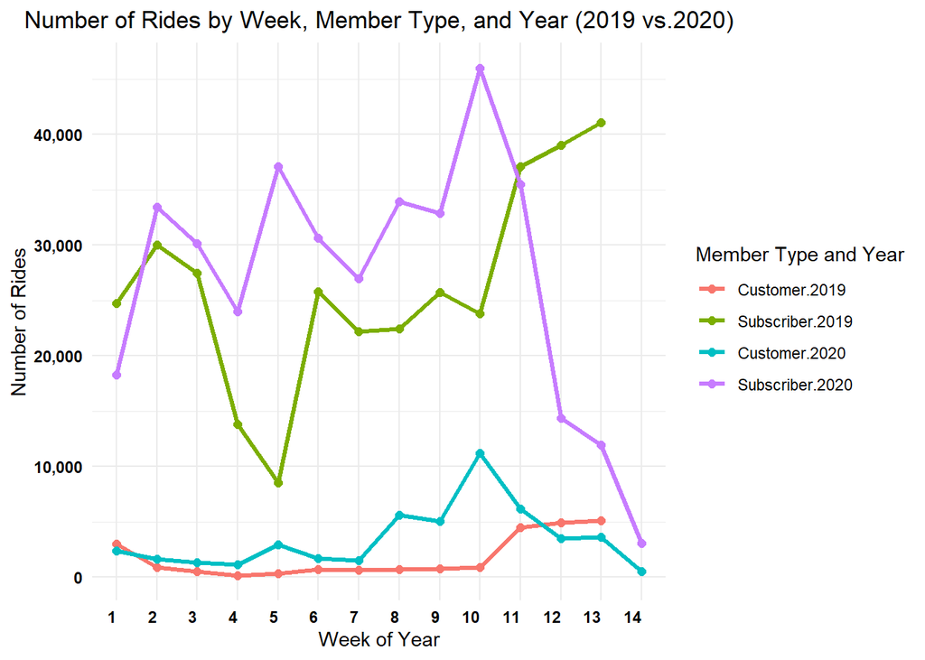

```r
#First Graph that works
rides_data_2019_2020 <- RidaDataForRV1 %>%
  filter(year(started_time) %in% c(2019, 2020)) %>%
  mutate(week_of_year = isoweek(started_time),
         year = year(started_time)) %>%
  group_by(member_casual, week_of_year, year) %>%
  summarise(num_rides = n(), .groups = 'drop')

# Create the line chart
ggplot(rides_data_2019_2020, aes(x = factor(week_of_year), y = num_rides, color = interaction(member_casual, year), group = interaction(member_casual, year))) +
  geom_line(size = 1.2) +  # Line thickness
  geom_point(size = 2) +   # Add points at each week
  scale_x_discrete(name = "Week of Year") +  # Set x-axis to discrete with label
  scale_y_continuous(labels = scales::comma) +  # Format y-axis labels
  labs(title = "Number of Rides by Week, Member Type, and Year (2019 vs.2020)",
       x = "Week of Year",
       y = "Number of Rides",
       color = "Member Type and Year") +  # Custom legend title
  theme_minimal() +
  theme(
    axis.text.x = element_text(color = "black", face = "bold", angle = 0, hjust = 1),
    axis.text.y = element_text(color = "black", face = "bold"),
    plot.title = element_text(hjust = 0.5)
  )
```

```r
#Second graph
# rides_data_2019_2020 <- RidaDataForRV1 %>%
#   filter(year(started_time) %in% c(2019, 2020)) %>%
#   mutate(week_of_year = isoweek(started_time),       # Extract ISO week number
#          year = year(started_time)) %>%             # Extract the year
#   group_by(member_casual, week_of_year, year) %>%
#   summarise(num_rides = n(), .groups = 'drop')  # Count the number of rides for each week, member type, and year
#
# # Create the line chart with labels for 2019 and 2020
# ggplot(rides_data_2019_2020, aes(x = factor(week_of_year), y = num_rides,
#                                  color = interaction(member_casual, year),
#                                  group = interaction(member_casual, year))) +
#   geom_line(size = 1.2) +  # Line thickness
#   geom_point(size = 2) +   # Add points at each week
#   geom_text(aes(label = scales::comma(round(num_rides, 0))), vjust = -0.5, size = 3) +  # Add rounded labels above points
#   scale_x_discrete(name = "Week of Year") +  # Set x-axis to discrete with label
#   scale_y_continuous(labels = scales::comma) +  # Format y-axis labels
#   labs(title = "Number of Rides by Week, Member Type, and Year (2019 vs. 2020)",
#        x = "Week of Year",
#        y = "Number of Rides",
#        color = "Member Type and Year") +  # Custom legend title
#   theme_minimal() +
#   theme(
#     axis.text.x = element_text(color = "black", face = "bold"),
#     axis.text.y = element_text(color = "black", face = "bold"),
#     plot.title = element_text(hjust = 0.5)
#   )

# # Third graph
# rides_data_2019_2020 <- RidaDataForRV1 %>%
#   filter(year(started_time) %in% c(2019, 2020)) %>%
#   mutate(week_of_year = isoweek(started_time),       # Extract ISO week number
#          year = year(started_time)) %>%             # Extract the year
#   group_by(member_casual, week_of_year, year) %>%
#   summarise(num_rides = n(), .groups = 'drop')  # Count the number of rides for each week, member type, and year
#
# # Create the line chart with labels for 2019 and 2020
# ggplot(rides_data_2019_2020, aes(x = factor(week_of_year), y = num_rides,
#                                  color = interaction(member_casual, year),
#                                  group = interaction(member_casual, year))) +
#   geom_line(size = 1.2) +  # Line thickness
#   geom_point(size = 2) +   # Add points at each week
#   # Add rounded labels only every 5th value
#   geom_text(data = rides_data_2019_2020 %>% filter(week_of_year %% 5 == 0),
#             aes(label = scales::comma(round(num_rides, 0))),
#             vjust = -0.5, size = 4) +
#   scale_x_discrete(name = "Week of Year") +  # Set x-axis to discrete with label
#   scale_y_continuous(labels = scales::comma) +  # Format y-axis labels
#   labs(title = "Number of Rides by Week, Member Type, and Year (2019 vs. 2020)",
#        x = "Week of Year",
#        y = "Number of Rides",
#        color = "Member Type and Year") +  # Custom legend title
#   theme_minimal() +
#   theme(
#     axis.text.x = element_text(color = "black", face = "bold"),
#     axis.text.y = element_text(color = "black", face = "bold"),
#     plot.title = element_text(hjust = 0.5)
#   )
```

#### Observations:

- This is a line graph of the Number of Rides by Week of Year and broken down by Customer and Subscriber. It is shown that for Customers in 2019 they were very low and rose slightly towards the end of the year. For Subscriber in 2019, they started out strong then saw a dip but rebounded and gradually increased over the rest of the weeks. For Customers in 2020, they started out low and saw a rapid increase at week 10 but then decreased rapidly after that. For Subscribers in 2020, they started off strong as they grew up until week 11 then saw a drastic decrease.

### Walkthrough:

- What is the change of Number of Rides by Customers and Subscribers over the Number of Weeks in 2019?

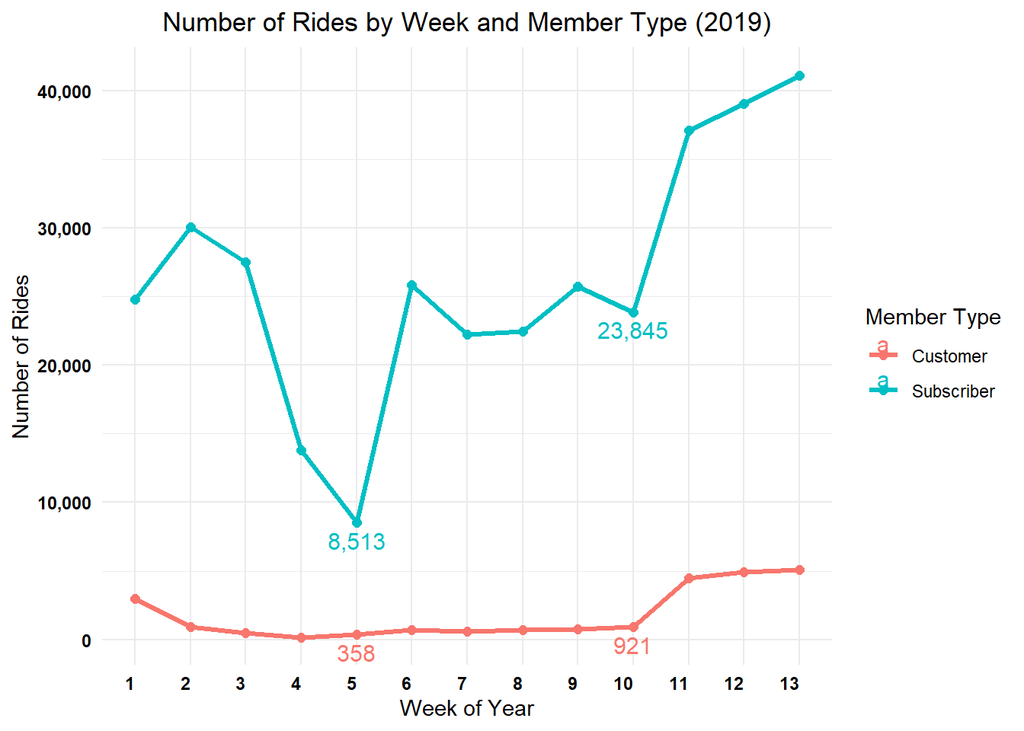

```r
rides_data_2019_2020 <- RidaDataForRV1 %>%
  filter(year(started_time) == 2019) %>%  # Filter data for 2019
  mutate(week_of_year = isoweek(started_time),  # Extract ISO week number
         year = year(started_time)) %>%  # Extract the year
  group_by(member_casual, week_of_year, year) %>%
  summarise(num_rides = n(), .groups = 'drop')  # Count the number of rides for each week, member type, and year

# Create the line chart
ggplot(rides_data_2019_2020, aes(x = factor(week_of_year), y = num_rides, color = member_casual, group = member_casual)) +
  geom_line(size = 1.2) +  # Line thickness
  geom_point(size = 2) +   # Optional: Add points at each week
  geom_text(data = rides_data_2019_2020 %>% filter(week_of_year %% 5 == 0),
            aes(label = scales::comma(round(num_rides, 0))),
            vjust = 1.5, size = 4) +
  scale_x_discrete(name = "Week of Year") +  # Set x-axis to discrete with label
  scale_y_continuous(labels = scales::comma) +  # Format y-axis labels
  labs(title = "Number of Rides by Week and Member Type (2019)",
       x = "Week of Year",
       y = "Number of Rides",
       color = "Member Type") +  # Custom legend title
  theme_minimal() +
  theme(
    axis.text.x = element_text(color = "black", face = "bold", angle = 0, hjust = 1),
    axis.text.y = element_text(color = "black", face = "bold"),
    plot.title = element_text(hjust = 0.5)
  )
```

#### Observations:

- This is a line graph that breaks down the previous graph but just the Custmer and Subscriber in 2019.

### Walkthrough:

- What is the change of Number of Rides by Customers and Subscribers over the Number of Weeks in 2020?

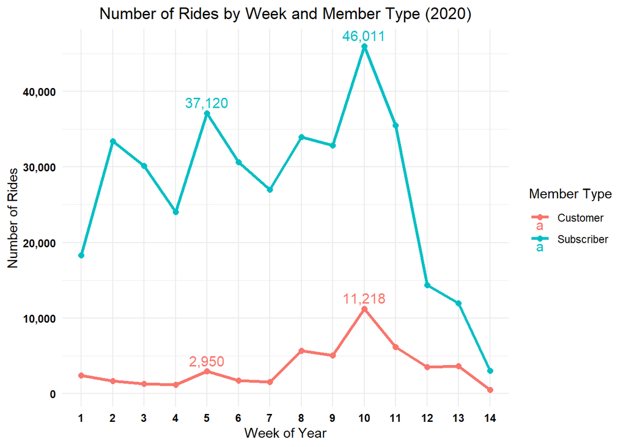

```r
# Filter data for the year 2020
rides_data_2020 <- RidaDataForRV1 %>%
  filter(year(started_time) == 2020) %>%
  mutate(week_of_year = isoweek(started_time),       # Extract ISO week number
         year = year(started_time)) %>%             # Extract the year
  group_by(member_casual, week_of_year, year) %>%
  summarise(num_rides = n(), .groups = 'drop')  # Count the number of rides for each week, member type, and year

# Create the line chart for 2020
ggplot(rides_data_2020, aes(x = factor(week_of_year), y = num_rides,
                            color = member_casual,
                            group = member_casual)) +
  geom_line(size = 1.2) +  # Line thickness
  geom_point(size = 2) +   # Add points at each week
  # Add rounded labels only every 5th value
  geom_text(data = rides_data_2020 %>% filter(week_of_year %% 5 == 0),
            aes(label = scales::comma(round(num_rides, 0))),
            vjust = -0.5, size = 4) +
  scale_x_discrete(name = "Week of Year") +  # Set x-axis to discrete with label
  scale_y_continuous(labels = scales::comma) +  # Format y-axis labels
  labs(title = "Number of Rides by Week and Member Type (2020)",
       x = "Week of Year",
       y = "Number of Rides",
       color = "Member Type") +  # Custom legend title
  theme_minimal() +
  theme(
    axis.text.x = element_text(color = "black", face = "bold"),
    axis.text.y = element_text(color = "black", face = "bold"),
    plot.title = element_text(hjust = 0.5)
  )
```

#### Observations:

- This is a line graph that breaks down the previous graph but just the Custmer and Subscriber in 2020.

### Walkthrough:

- What End Station has the Highest Number of Rides?

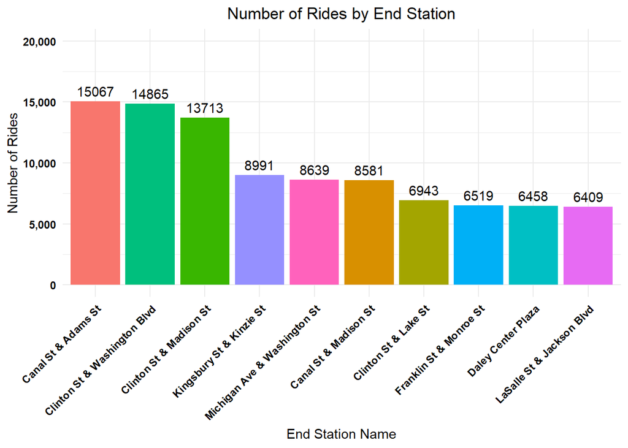

```r
rides_data_by_station <- RidaDataForRV1 %>%
  group_by(end_station_name) %>%
  summarise(num_rides = n(), .groups = 'drop')  # Count the number of rides per station

# Sort by the number of rides in descending order to have a better visualization
rides_data_sorted <- rides_data_by_station %>%
  arrange(desc(num_rides)) %>%
  head(10)  # Optionally show the top 10 stations

# Create the bar chart
ggplot(rides_data_sorted, aes(x = reorder(end_station_name, -num_rides), y = num_rides, fill = end_station_name)) +
  geom_bar(stat = "identity") +
  geom_text(aes(label = num_rides), vjust = -0.5) +  # Add text labels above the bars
  ylim(0, 20000) +
  scale_y_continuous(labels = scales::comma, limits = c(0, 20000)) +  # Format y-axis labels
  labs(title = "Number of Rides by End Station",
       x = "End Station Name",
       y = "Number of Rides") +
  theme_minimal() +
  theme(
    axis.text.x = element_text(angle = 45, hjust = 1, color = "black", face = "bold"),  # Rotate x-axis labels
    axis.text.y = element_text(color = "black", face = "bold"),
    plot.title = element_text(hjust = 0.5),
    legend.position = "none"  # Hide legend
  )
```

#### Observations:

- This Bar Chart breaks down the Number of Rides by End Station. It is clear that the Highest Number of Rides by End Station is Canal St & Adams St followed closely by Clifton St & Washington BLV.

### Walkthrough:

- What End Station has the Highest Ride Duration in Minutes?

[figure not shown]

```r
rides_duration_by_station <- RidaDataForRV1 %>%
  group_by(end_station_name) %>%
  summarise(total_ride_duration_minutes = sum(ride_duration_minutes, na.rm = TRUE), .groups = 'drop')  # Sum of ride durations

# Sort by the total ride duration in descending order to have a better visualization
rides_duration_sorted <- rides_duration_by_station %>%
  arrange(desc(total_ride_duration_minutes)) %>%
  head(10)  # Optionally show the top 10 stations

# Create the bar chart
ggplot(rides_duration_sorted, aes(x = reorder(end_station_name, -total_ride_duration_minutes), y = total_ride_duration_minutes, fill = end_station_name)) +
  geom_bar(stat = "identity") +
  geom_text(aes(label = scales::comma(round(total_ride_duration_minutes, 0))), vjust = -0.5) +  # Add text labels above the bars
  scale_y_continuous(labels = scales::comma, limits = c(0, 350000)) +  # Format y-axis labels
  labs(title = "Total Ride Duration (Minutes) by End Station",
       x = "End Station Name",
       y = "Total Ride Duration (minutes)") +
  theme_minimal() +
  theme(
    axis.text.x = element_text(angle = 90, hjust = 1, color = "black", face = "bold", size = 8),  # Rotate x-axis labels
    axis.text.y = element_text(color = "black", face = "bold"),
    plot.title = element_text(hjust = 0.5),
    legend.position = "none"  # Hide legend
  )
```

#### Observations:

- This Bar Chart breaks down the Total Ride Duration in Minutes by the End Station Name. It is clear that Hubbard St Bike Checkpoint had the highest Total Ride Duration.

### Walkthrough:

- How does the Ride Duration in Minutes relate to the Top 5 Start Station Names?

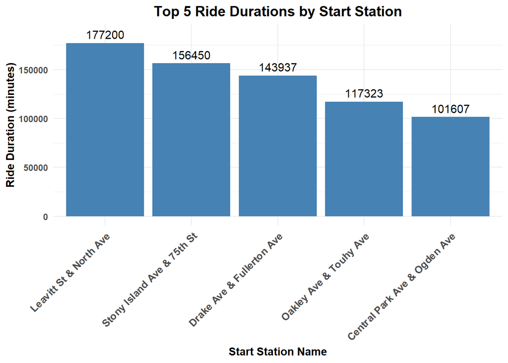

```r
RidaDataForRV1_sorted <- RidaDataForRV1 %>%
  arrange(desc(ride_duration_minutes)) %>%
  head(5)
ggplot(RidaDataForRV1_sorted, aes(x = reorder(start_station_name, -ride_duration_minutes), y = ride_duration_minutes)) +
  geom_bar(stat = "identity", fill = "steelblue") +
  geom_text(aes(label = round(ride_duration_minutes, 0)), vjust = -0.5, color = "black", size = 4) +  # Round ride duration
  labs(title = "Top 5 Ride Durations by Start Station",
       x = "Start Station Name",
       y = "Ride Duration (minutes)") +
  theme_minimal() +
  theme(
    axis.text.x = element_text(angle = 45, hjust = 1, vjust = 1, size = 10, face = "bold"),  # Angled labels with better spacing
    axis.text.y = element_text(face = "bold"),
    plot.title = element_text(hjust = 0.5, face = "bold", size = 14),  # Centered and bold title
    axis.title.x = element_text(face = "bold"),
    axis.title.y = element_text(face = "bold")
  ) +
  ylim(0, max(RidaDataForRV1_sorted$ride_duration_minutes) + 10000)  # Dynamic y-axis scaling based on the data
```

#### Observations:

- This Bar Plot shows the Ride Duration in Minutes with the Top 5 Start Station Locations. It shows that the Start Station with the highest Ride Duration in Minutes is Leavitt St & North Ave.

### Walkthrough:

- How do the Number of Rides and Start Station Name affect by Subscriber?

```r
rides_data <- RidaDataForRV1 %>%
  filter(member_casual == 'Subscriber') %>%
  group_by(start_station_name) %>%
  summarise(num_rides = n()) %>%
  ungroup()
#print(rides_data)

rides_data_sorted <- rides_data %>%
  arrange(desc(num_rides)) %>%
  head(15)
  #print(rides_data_sorted)

max_num_rides <- max(rides_data_sorted$num_rides, na.rm =TRUE)
print(max_num_rides)
```

```
## [1] 13799
```

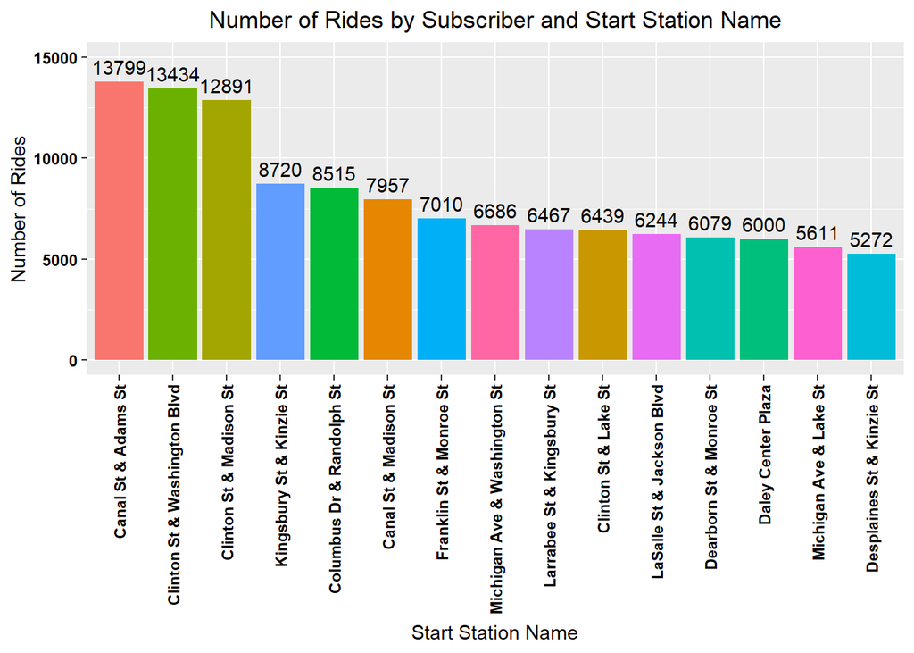

```r
ggplot(rides_data_sorted, aes(x = reorder(start_station_name, -num_rides), y = num_rides, fill = start_station_name)) +
  theme(axis.text.x = element_text(angle = 90, hjust = 1, vjust = 0.5)) +
  geom_text(aes(label = num_rides), vjust = -0.5) +
  ylim(0, max_num_rides + 1200) +
  geom_bar(stat = "identity") +
  labs(title = "Number of Rides by Subscriber and Start Station Name",
       x = "Start Station Name", y = "Number of Rides") +
  theme(legend.position = "none") +
  theme(
    axis.text.x = element_text(color = "black", face = "bold"),
    axis.text.y = element_text(color = "black", face = "bold"),
    plot.title = element_text(hjust = 0.5)
  )
```

#### Observations:

- This Bar Chart shows the Number of Rides versus the Start Station Name with just Subscribers in desceinding order. It is shown in the graph that these start locations are not toursit attractions. For the Subscribers, they use the Bike Service for a structured reason as opposed to the Customers who use the Bike Service for entertainment purposes.

### Walkthrough:

- What are the top End Stations by Number of Rides and by Subscriber?

```r
rides_data <- RidaDataForRV1 %>%
  filter(member_casual == 'Subscriber') %>%
  group_by(end_station_name) %>%
  summarise(num_rides = n()) %>%
  ungroup()
#print(rides_data)

rides_data_sorted <- rides_data %>%
  arrange(desc(num_rides)) %>%
  head(15)
  #print(rides_data_sorted)

max_num_rides <- max(rides_data_sorted$num_rides, na.rm =TRUE)
print(max_num_rides)
```

```
## [1] 14807
```

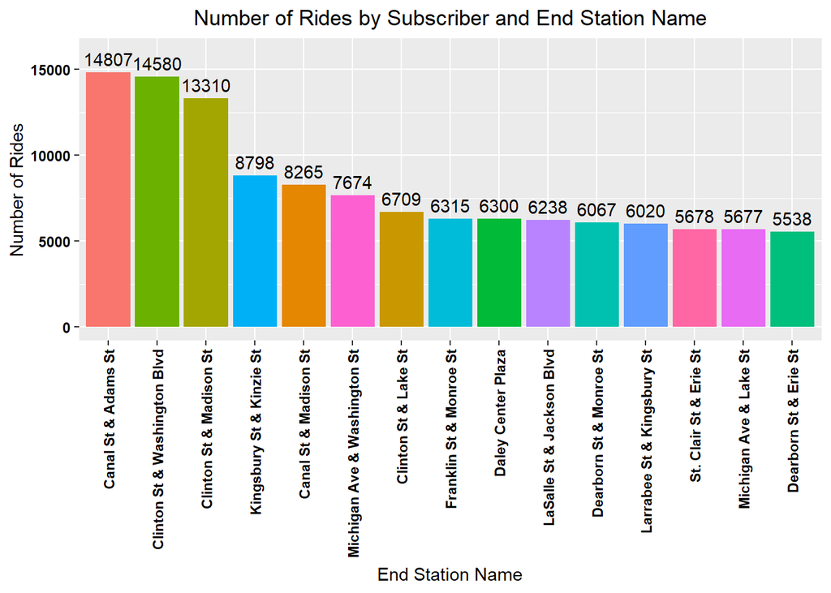

```r
ggplot(rides_data_sorted, aes(x = reorder(end_station_name, -num_rides), y = num_rides, fill = end_station_name)) +
  theme(axis.text.x = element_text(angle = 90, hjust = 1, vjust = 0.5)) +
  geom_text(aes(label = num_rides), vjust = -0.5) +
  ylim(0, max_num_rides + 1200) +
  geom_bar(stat = "identity") +
  labs(title = "Number of Rides by Subscriber and End Station Name",
       x = "End Station Name", y = "Number of Rides") +
  theme(legend.position = "none") +
  theme(
    axis.text.x = element_text(color = "black", face = "bold"),
    axis.text.y = element_text(color = "black", face = "bold"),
    plot.title = element_text(hjust = 0.5)
  )
```

#### Observations:

- This Bar Chart shows the Number of Rides by the End Station Name and by Subscriber.

### Walkthrough:

- What Start Station has the Highest Number of Rides by Customer?

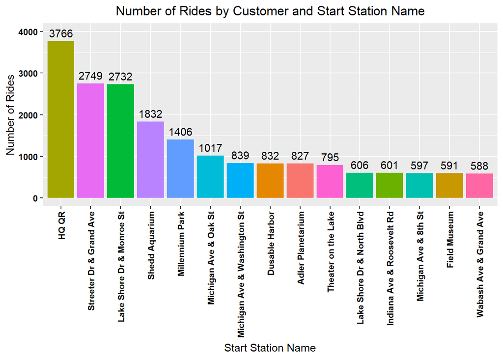

```r
rides_data <- RidaDataForRV1 %>%
  filter(member_casual == 'Customer') %>%
  group_by(start_station_name) %>%
  summarise(num_rides = n()) %>%
  ungroup()
#print(rides_data)

rides_data_sorted <- rides_data %>%
  arrange(desc(num_rides)) %>%
  head(15)
  #print(rides_data_sorted)


ggplot(rides_data_sorted, aes(x = reorder(start_station_name, -num_rides), y = num_rides, fill = start_station_name)) +
  theme(axis.text.x = element_text(angle = 90, hjust = 1, vjust = 0.5)) +
  geom_text(aes(label = num_rides), vjust = -0.5) +
  geom_bar(stat = "identity") +
  ylim(0, 4000) +
  labs(title = "Number of Rides by Customer and Start Station Name",
       x = "Start Station Name", y = "Number of Rides") +
  theme(legend.position = "none") +
  theme(
    axis.text.x = element_text(color = "black", face = "bold"),
    axis.text.y = element_text(color = "black", face = "bold"),
    plot.title = element_text(hjust = 0.5)
  )
```

#### Observations:

- This Bar Chart shows the Number of Rides versus the Start Station Name with just Customers while in descending order. It is evident that these locations are tourist attractions with locations such as Field Muesum, Shedd Aquarium, Dusable Harbor and Adler Planeterium.

### Walkthrough:

- What End Station Name has the Highest Number of Rides by Customer?

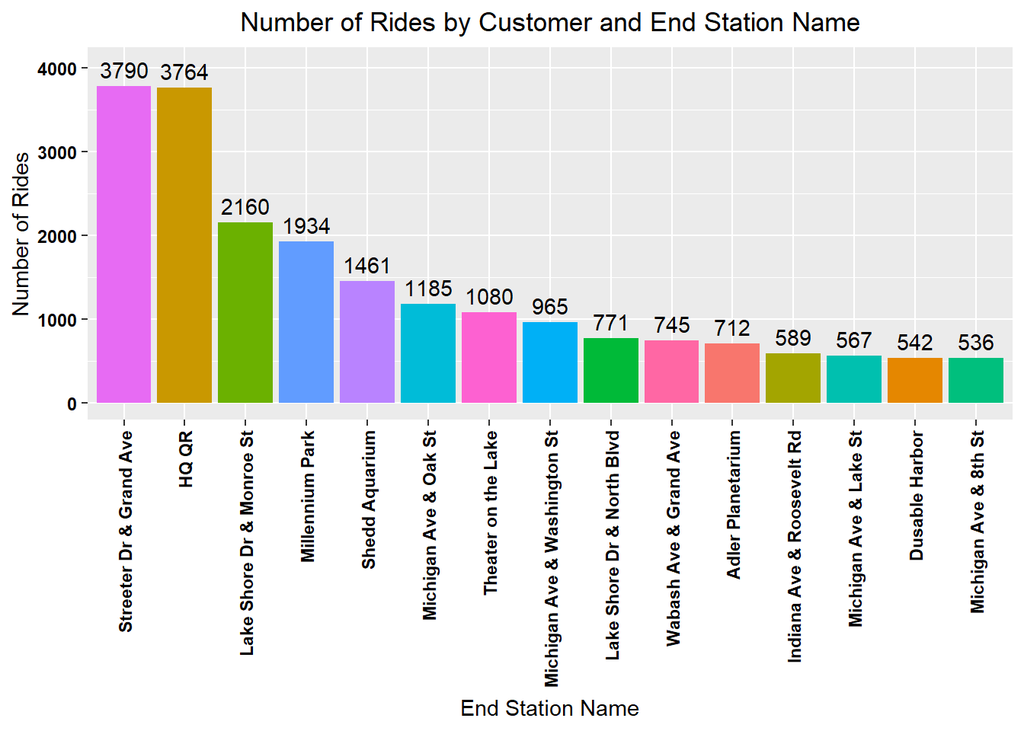

```r
rides_data <- RidaDataForRV1 %>%
  filter(member_casual == 'Customer') %>%
  group_by(end_station_name) %>%
  summarise(num_rides = n()) %>%
  ungroup()
#print(rides_data)

rides_data_sorted <- rides_data %>%
  arrange(desc(num_rides)) %>%
  head(15)
  #print(rides_data_sorted)


ggplot(rides_data_sorted, aes(x = reorder(end_station_name, -num_rides), y = num_rides, fill = end_station_name)) +
  theme(axis.text.x = element_text(angle = 90, hjust = 1, vjust = 0.5)) +
  geom_text(aes(label = num_rides), vjust = -0.5) +
  geom_bar(stat = "identity") +
  ylim(0, 4050) +
  labs(title = "Number of Rides by Customer and End Station Name",
       x = "End Station Name", y = "Number of Rides") +
  theme(legend.position = "none") +
  theme(
    axis.text.x = element_text(color = "black", face = "bold"),
    axis.text.y = element_text(color = "black", face = "bold"),
    plot.title = element_text(hjust = 0.5)
  )
```

#### Observations:

- This Bar Chart shows the Number of Rides by the End Station Name and by Customer. The End Station with the most Number of Rides is Streeter Dr & Grand Ave followed closely by HQ QR.

### Walkthrough:

- What Start Station Name has the Highest Ride Duration Minutes by Customer?

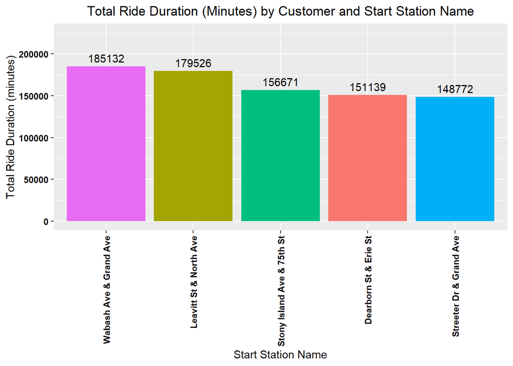

```r
# New Plot for Ride Duration Minutes
 rides_data <- RidaDataForRV1 %>%
  filter(member_casual == 'Customer') %>%
  group_by(start_station_name) %>%
  summarise(total_ride_duration_minutes = sum(ride_duration_minutes, na.rm = TRUE)) %>%
  ungroup()

rides_data_sorted <- rides_data %>%
  arrange(desc(total_ride_duration_minutes)) %>%
  head(5)

max_ride_duration <- max(rides_data_sorted$total_ride_duration_minutes, na.rm = TRUE)

ggplot(rides_data_sorted, aes(x = reorder(start_station_name, -total_ride_duration_minutes), y = total_ride_duration_minutes, fill = start_station_name)) +
  geom_bar(stat = "identity") +
  geom_text(aes(label = round(total_ride_duration_minutes, 0)), vjust = -0.5) +  # Round and display labels
  ylim(0, max_ride_duration + 40000) +  # Set y-axis limit slightly above the max value
  labs(title = "Total Ride Duration (Minutes) by Customer and Start Station Name",
       x = "Start Station Name",
       y = "Total Ride Duration (minutes)") +
  theme(axis.text.x = element_text(angle = 90, hjust = 1, vjust = 0.5, color = "black", face = "bold"),
        axis.text.y = element_text(color = "black", face = "bold"),
        plot.title = element_text(hjust = 0.5),
        legend.position = "none")  # Remove legend
```

#### Observations:

- This Bar Chart shows the Total Ride DUration by the Start Station Name and broken down by Customer. The Start Station with the highest Ride Duration is Wabash Ave & Grand Ave.

### Walkthrough:

- What Start Station Name has the Highest Ride Duration in Minutes based on Subscriber?

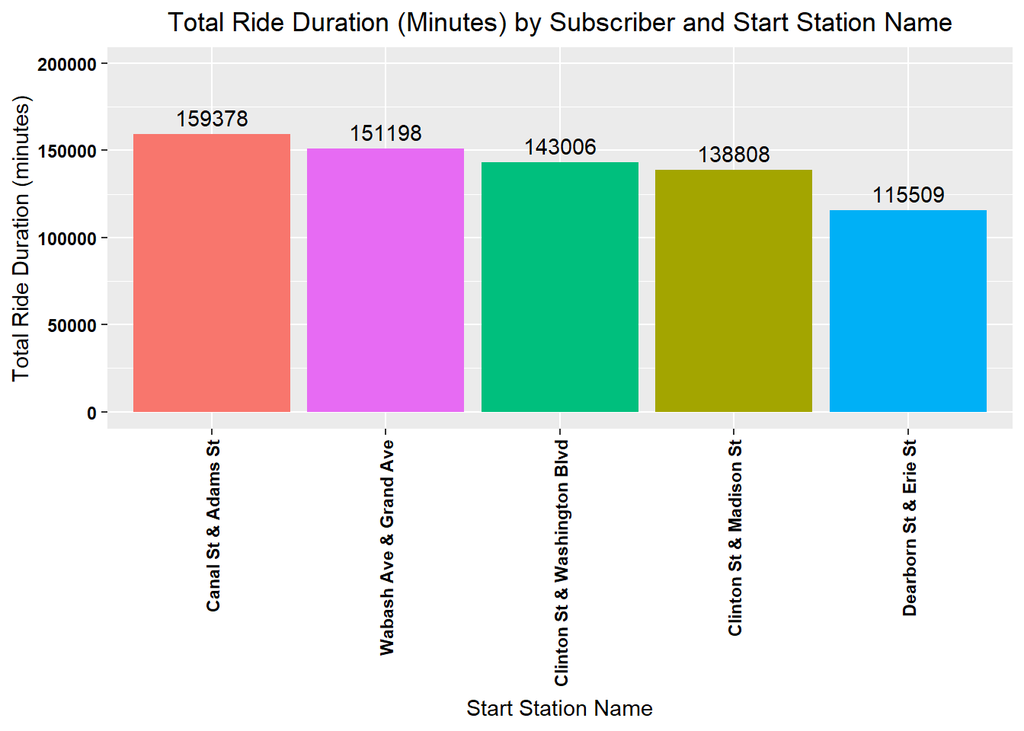

```r
# New Plot for Ride Duration Minutes
 rides_data <- RidaDataForRV1 %>%
  filter(member_casual == 'Subscriber') %>%
  group_by(start_station_name) %>%
  summarise(total_ride_duration_minutes = sum(ride_duration_minutes, na.rm = TRUE)) %>%
  ungroup()

rides_data_sorted <- rides_data %>%
  arrange(desc(total_ride_duration_minutes)) %>%
  head(5)

max_ride_duration <- max(rides_data_sorted$total_ride_duration_minutes, na.rm = TRUE)

ggplot(rides_data_sorted, aes(x = reorder(start_station_name, -total_ride_duration_minutes), y = total_ride_duration_minutes, fill = start_station_name)) +
  geom_bar(stat = "identity") +
  geom_text(aes(label = round(total_ride_duration_minutes, 0)), vjust = -0.5) +  # Round and display labels
  ylim(0, max_ride_duration + 40000) +  # Set y-axis limit slightly above the max value
  labs(title = "Total Ride Duration (Minutes) by Subscriber and Start Station Name",
       x = "Start Station Name",
       y = "Total Ride Duration (minutes)") +
  theme(axis.text.x = element_text(angle = 90, hjust = 1, vjust = 0.5, color = "black", face = "bold"),
        axis.text.y = element_text(color = "black", face = "bold"),
        plot.title = element_text(hjust = 0.5),
        legend.position = "none")  # Remove legend
```

#### Observations:

- This graph looks at the Total Ride Duation by the Start Station Name and breaks it down by Subscriber. The Station with the top Duration is Canal St.

### Walkthrough:

- What End Station has the Highest Ride Duration in Minutes based on Customer?

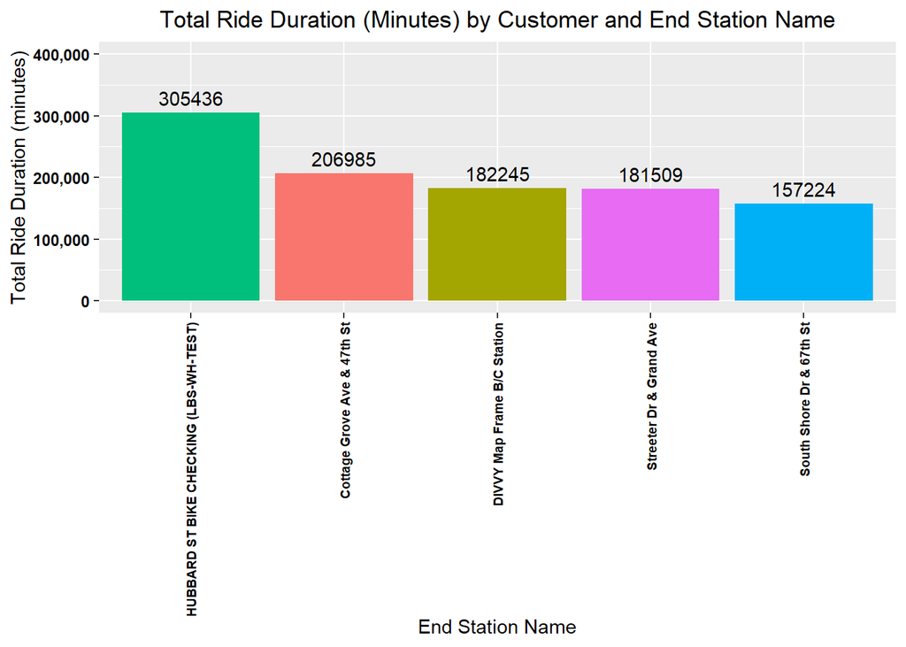

```r
# New Plot for Ride Duration Minutes
 rides_data <- RidaDataForRV1 %>%
  filter(member_casual == 'Customer') %>%
  group_by(end_station_name) %>%
  summarise(total_ride_duration_minutes = sum(ride_duration_minutes, na.rm = TRUE)) %>%
  ungroup()

rides_data_sorted <- rides_data %>%
  arrange(desc(total_ride_duration_minutes)) %>%
  head(5)

max_ride_duration <- max(rides_data_sorted$total_ride_duration_minutes, na.rm = TRUE)

ggplot(rides_data_sorted, aes(x = reorder(end_station_name, -total_ride_duration_minutes), y = total_ride_duration_minutes, fill = end_station_name)) +
  geom_bar(stat = "identity") +
  geom_text(aes(label = round(total_ride_duration_minutes, 0)), vjust = -0.5) +
  ylim(0, max_ride_duration + 150000) +  # Set y-axis limit slightly above the max value
  scale_y_continuous(labels = scales::comma, limits = c(0, 400000)) +
  labs(title = "Total Ride Duration (Minutes) by Customer and End Station Name",
       x = "End Station Name",
       y = "Total Ride Duration (minutes)") +
  theme(axis.text.x = element_text(angle = 90, hjust = 1, vjust = 0.5, color = "black", face = "bold", size = 7),
        axis.text.y = element_text(color = "black", face = "bold"),
        plot.title = element_text(hjust = 0.5),
        legend.position = "none")
```

#### Observations:

- This graph looks at the Total Ride Duration and the End Station Name and breaks it down by Customer. The End Station with the highest Duration is Hubbard St Bike Checking.

### Walkthrough:

- What End Station Name has the Highest Ride Duration in Minutes based on Subscriber?

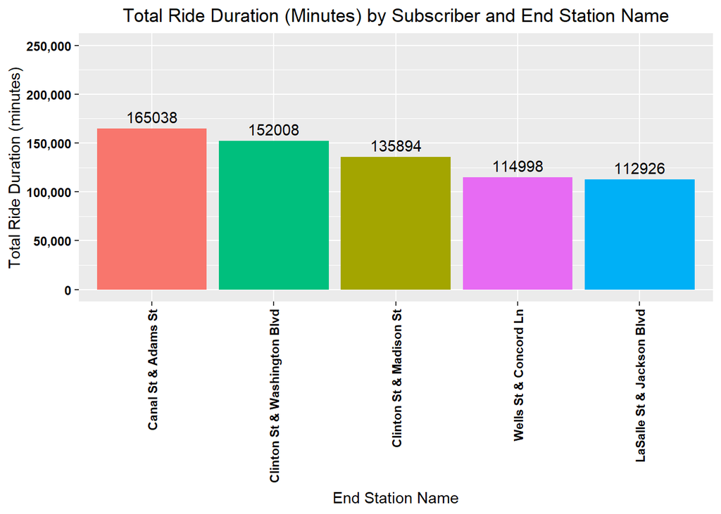

```r
# New Plot for Ride Duration Minutes
 rides_data <- RidaDataForRV1 %>%
  filter(member_casual == 'Subscriber') %>%
  group_by(end_station_name) %>%
  summarise(total_ride_duration_minutes = sum(ride_duration_minutes, na.rm = TRUE)) %>%
  ungroup()

# Sort the data to get the top 5 stations by total ride duration
rides_data_sorted <- rides_data %>%
  arrange(desc(total_ride_duration_minutes)) %>%
  head(5)

max_ride_duration <- max(rides_data_sorted$total_ride_duration_minutes, na.rm = TRUE)

ggplot(rides_data_sorted, aes(x = reorder(end_station_name, -total_ride_duration_minutes), y = total_ride_duration_minutes, fill = end_station_name)) +
  geom_bar(stat = "identity") +
  geom_text(aes(label = round(total_ride_duration_minutes, 0)), vjust = -0.5) +  # Round and display labels
  ylim(0, max_ride_duration + 100000) +  # Set y-axis limit slightly above the max value
  scale_y_continuous(labels = scales::comma, limits = c(0, 250000)) +
  labs(title = "Total Ride Duration (Minutes) by Subscriber and End Station Name",
       x = "End Station Name",
       y = "Total Ride Duration (minutes)") +
  theme(axis.text.x = element_text(angle = 90, hjust = 1, vjust = 0.5, color = "black", face = "bold"),
        axis.text.y = element_text(color = "black", face = "bold"),
        plot.title = element_text(hjust = 0.5),
        legend.position = "none")  # Remove legend
```

#### Observations:

- This Bar Chart looks at the Total Ride Duration by the End Station Name and breaks it down by Subscriber. The Station with the highest Duration is Canal St which is a common Station Name.

### Walkthrough:

- How does Ride Duration in Minutes affect Customers versus Subscribers differently?

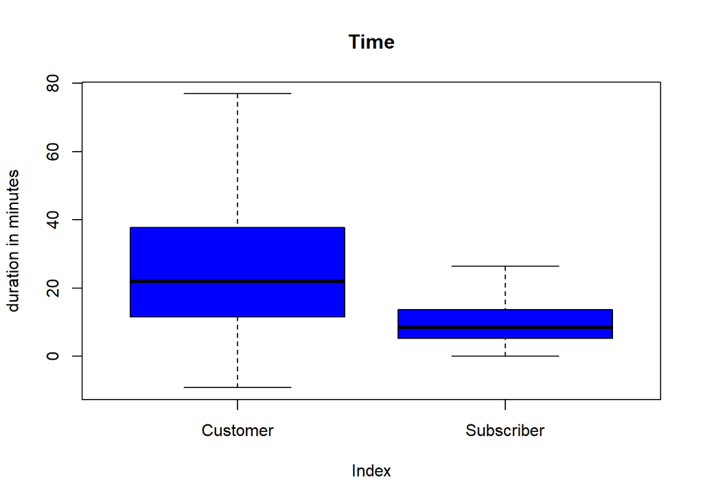

```r
bp<-boxplot(ride_duration_minutes ~ member_casual, data = RidaDataForRV1, outline = FALSE,
     main = "Time",
     xlab = "Index",
     ylab = "duration in minutes",
     pch = 19,
     col = "blue")
```

```r
print_stats(bp)
```

```
##   BoxPlot Category =  Customer
##   Upper Whisker:  76.86667
##   Q3           :  37.68333
##   Median       :  22
##   Q1           :  11.55
##   Lower Whisker:  -9.2
##   Q3 - Q1      :  26.13333
##
##   BoxPlot Category =  Subscriber
##   Upper Whisker:  26.36667
##   Q3           :  13.71667
##   Median       :  8.466666
##   Q1           :  5.283334
##   Lower Whisker:  0.01666658
##   Q3 - Q1      :  8.433333
```

```r
# for(i in 1:length(bp$n)) {
#   cat("BoxPlot Category = ",bp$names[i], "\n")
#   cat("Upper Whisker: ",bp$stats[5, i], "\n")
#   cat("Q3: ",bp$stats[4, i], "\n")
#   cat("Median: ",bp$stats[3, i], "\n")
#   cat("Q1: ",bp$stats[2, i], "\n")
#   cat("Lower Whisker: ",bp$stats[1, i], "\n")
#   cat("Q3 - Q1: ",bp$stats[4, i] - bp$stats[2, i], "\n")
# }
```

### Observations:

- How does Day of the Week affect Customer versus Subscriber differently?

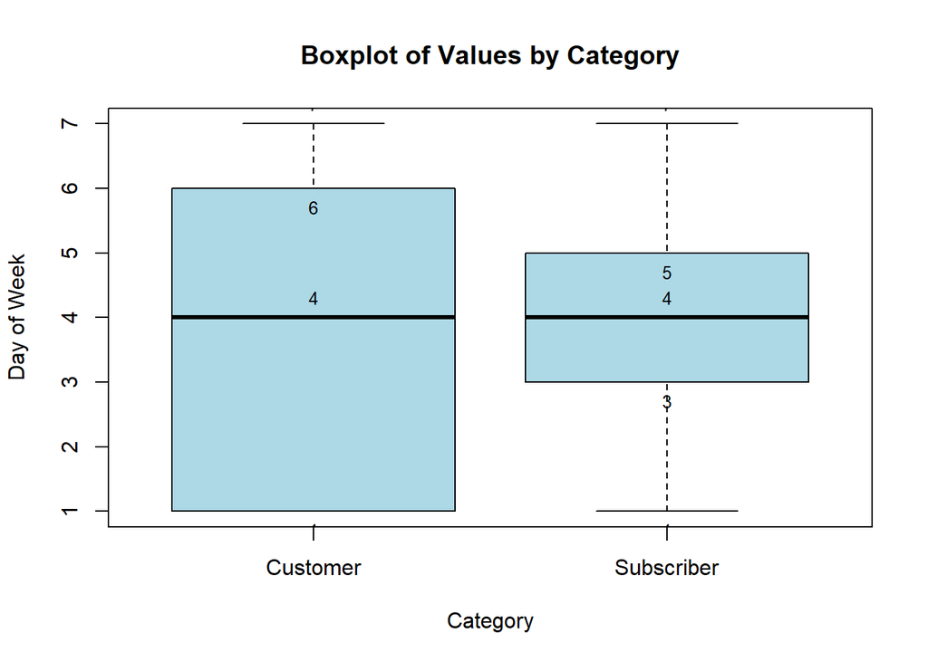

```
## [1] "hello"
## [1] "hello"
```

```r
bp <- boxplot(day_of_week ~ member_casual, data = RidaDataForRV1,
        main = "Boxplot of Values by Category",
        xlab = "Category",
        ylab = "Day of Week",
        col = "lightblue")

for(i in 1:length(bp$n)) {
  print ("hello")
  text(i, bp$stats[1, i], labels = round(bp$stats[1, i], 2), pos   = 1, cex = 0.8)
  text(i, bp$stats[2, i], labels = round(bp$stats[2, i], 2), pos   = 1, cex = 0.8)
  text(i, bp$stats[3, i], labels = round(bp$stats[3, i], 2), pos   = 3, cex = 0.8)
  text(i, bp$stats[4, i], labels = round(bp$stats[4, i], 2), pos   = 1, cex = 0.8)
  text(i, bp$stats[5, i], labels = round(bp$stats[5, i], 2), pos   = 3, cex = 0.8)
}
```

#### Observations:

- This graph shows the difference between Customers and Subscribers and when the Day of Week that they ride. It shows that median is the same being the fourth day of the week.

#### Observations:

- The Max Started Time in 2019 was March 31, 2019 at 11:53 pm Eastern Daylight Time.

```r
# Ensure that the started_time column is in datetime format
RidaDataForRV1$started_time <- as.POSIXct(RidaDataForRV1$started_time, format = "%Y-%m-%d %H:%M:%S")

# Filter the data for the year 2019
rides_2019 <- RidaDataForRV1 %>%
  filter(format(started_time, "%Y") == "2019")

# Find the maximum started_time in 2019
max_started_time_2019 <- max(rides_2019$started_time, na.rm = TRUE)

# Print the result
print(max_started_time_2019)
```

```
## [1] "2019-03-31 23:53:48 EDT"
```

#### Observations:

- The Minimum Started Time in 2019 was January 01, 2019 at 12:08 am Eastern Standard Time.

```r
# Ensure that the started_time column is in datetime format
RidaDataForRV1$started_time <- as.POSIXct(RidaDataForRV1$started_time, format = "%Y-%m-%d %H:%M:%S")

# Filter the data for the year 2019
rides_2019 <- RidaDataForRV1 %>%
  filter(format(started_time, "%Y") == "2019")

# Find the min started_time in 2019
min_started_time_2019 <- min(rides_2019$started_time, na.rm = TRUE)

# Print the result
print(min_started_time_2019)
```

```
## [1] "2019-01-01 00:08:13 EST"
```

#### Observations:

```r
# Ensure that the ended_time column is in datetime format
RidaDataForRV1$ended_time <- as.POSIXct(RidaDataForRV1$ended_time, format = "%Y-%m-%d %H:%M:%S")

# Filter the data for the year 2019
rides_2019 <- RidaDataForRV1 %>%
  filter(format(ended_time, "%Y") == "2019")

# Find the maximum ended_time in 2019
max_ended_time_2019 <- max(rides_2019$ended_time, na.rm = TRUE)

# Print the result
print(max_ended_time_2019)
```

```
## [1] "2019-06-17 16:04:35 EDT"
```

#### Observations:

- The Minimum Ended Time in 2019 was January, 01, 2019 at 12:15 am Eastern Standard Time.

```r
# Ensure that the ended_time column is in datetime format
RidaDataForRV1$ended_time <- as.POSIXct(RidaDataForRV1$ended_time, format = "%Y-%m-%d %H:%M:%S")

# Filter the data for the year 2019
rides_2019 <- RidaDataForRV1 %>%
  filter(format(ended_time, "%Y") == "2019")

# Find the maximum ended_time in 2019
min_ended_time_2019 <- min(rides_2019$ended_time, na.rm = TRUE)

# Print the result
print(min_ended_time_2019)
```

```
## [1] "2019-01-01 00:15:34 EST"
```

#### Observations:

- The Maximum Started Time in 2020 was March 31, 2020 at 11:51 pm Eastern Daylight Time.

```r
# Ensure that the started_time column is in datetime format
RidaDataForRV1$started_time <- as.POSIXct(RidaDataForRV1$started_time, format = "%Y-%m-%d %H:%M:%S")

# Filter the data for the year 2020
rides_2020 <- RidaDataForRV1 %>%
  filter(format(started_time, "%Y") == "2020")

# Find the maximum started_time in 2020
max_started_time_2020 <- max(rides_2020$started_time, na.rm = TRUE)

# Print the result
print(max_started_time_2020)
```

```
## [1] "2020-03-31 23:51:34 EDT"
```

#### Observations:

- The Minimum Started Time in 2020 was Janurary 01, 2020 at 12:04 am Eastern Standard Time.

```r
# Ensure that the started_time column is in datetime format
RidaDataForRV1$started_time <- as.POSIXct(RidaDataForRV1$started_time, format = "%Y-%m-%d %H:%M:%S")

# Filter the data for the year 2020
rides_2020 <- RidaDataForRV1 %>%
  filter(format(started_time, "%Y") == "2020")

# Find the min started_time in 2020
min_started_time_2020 <- min(rides_2020$started_time, na.rm = TRUE)

# Print the result
print(min_started_time_2020)
```

```
## [1] "2020-01-01 00:04:44 EST"
```

#### Observations:

- The Maximum Ended Time in 2020 was May 19, 2020 at 8:10 pm Eastern Daylight Time.

```r
# Ensure that the ended_time column is in datetime format
RidaDataForRV1$ended_time <- as.POSIXct(RidaDataForRV1$ended_time, format = "%Y-%m-%d %H:%M:%S")

# Filter the data for the year 2020
rides_2020 <- RidaDataForRV1 %>%
  filter(format(ended_time, "%Y") == "2020")

# Find the maximum ended_time in 2020
max_ended_time_2020 <- max(rides_2020$ended_time, na.rm = TRUE)

# Print the result
print(max_ended_time_2020)
```

```
## [1] "2020-05-19 20:10:34 EDT"
```

#### Observations:

- The Minimum Ended Time in 2020 was January 01, 2020 at 12:10 am Eastern Standard Time.

```r
# Ensure that the ended_time column is in datetime format
RidaDataForRV1$ended_time <- as.POSIXct(RidaDataForRV1$ended_time, format = "%Y-%m-%d %H:%M:%S")

# Filter the data for the year 2020
rides_2020 <- RidaDataForRV1 %>%
  filter(format(ended_time, "%Y") == "2020")

# Find the maximum ended_time in 2020
min_ended_time_2020 <- min(rides_2020$ended_time, na.rm = TRUE)

# Print the result
print(min_ended_time_2020)
```

```
## [1] "2020-01-01 00:10:54 EST"
```

```r
#str(RidaDataForRV1)
```

```r
#summary(RidaDataForRV1)
```

```r
#quantile(RidaDataForRV1$ride_duration_minutes, probs=c(0,0.25,0.5,0.75,1))
```

```r
# conn <- dbConnect(RSQLite::SQLite(), dbname = "C:\\Users\\mjgon\\OneDrive\\Desktop\\Case #Study Data\\csv files\\Cyclistic_DB")
# query <- "SELECT start_station_name, COUNT(*) AS ride_count
# FROM RideData
# GROUP BY start_station_name
# ORDER BY ride_count DESC
# LIMIT 10"
#
# result <- dbGetQuery(conn, query)
# print(result)
#
#
# dbDisconnect(conn)
```

### Conclusion:

- For this proect I was tasked at the first question which was “How do annual members and casual riders use Cyclistic bikes differently?” I will be answering each of the three questions in detail.
- How do annual members and casual riders use Cyclistic bikes differently? Annual members use this bike system much more than the customers do. When broken down by the number of rides the annual members had 720,000 rides while the customers only had 71,000. Based on this data alone, it can be concluded that targeting the customers to try and convert them into annual members may not be the best use of resources. While there are customers to go after and convert, they are a small margin in all of the data that was collected.
- Why would casual riders be motivated to purchase annual memberships? Casual riders would be motivated to purchase memberships because of the cost savings, convience, and for health and fitness. If the user is planning on using the bikes to commute to work then this is an excellent choice to switch to an annual member because the user will be using it on a daily basis. Another reason is for the health and fitness that riding a bike more consistantly brings. Also, Cyclistic brings a convience to people’s daily lives by offering a mode of transportation.
- How can digital media be leveraged to influence casual riders to convert to annual members? Digital media can be leveraged to influence casual riders to convert to annual members by placing ads in the most used start and end locations. If these customers saw that they could be benefited by switching to an annual membership they would be more inclinded to do so. The start station with the highest number of rides by customer was HQ QR. The end station with the highest number of rides by customer was Streeter Dr & Grand Ave. By placing ads in both of these locations specifically, the customers are more inclinded to switch to an annual membership.

[output not shown]